# LEGALST 123 Modeling Part 1

Maggie Siu, Ashutosh Bhadouria, Jessica Ornowski

4/23/2021

# Introduction

The goal of this section is to find the average treatment effect of carbon pricing policy interventions on the national level on greenhouse gas emissions. In other words, we want to see whether implementing carbon pricing policies will help us decrease greenhouse gas emissions in a country. This is an observational time series cross section (TSCS) study.

While many economic and clinical studies make use of randomized controlled trials to measure the impact of an intervention, we cannot do this using an observational study like the one we have here. In social science, a conventional solution to this would be to perform a linear regression analysis using time and unit fixed effects. However, this sometimes introduces biases into the results, so in this study, we will be using a score-matching model with the difference-in-difference approach to help us evaluate the average treatment effect of carbon pricing policies on greenhouse gas emissions on the national level. The foundation of this TSCS empirical model was first created by Imai, Kim, and Wang, 2020 in hopes of bridging the gap between the matching models approach and TCSC studies. We will be applying their model to our study.

More information can be found about the model in the following links:

- http://web.mit.edu/insong/www/pdf/tscs.pdf
- https://github.com/insongkim/PanelMatch

# Model

With the climate change crisis being a global threat, countries have been working together to help slow and reverse the impacts of rising greenhouse gas emissions. Multiple mitigation efforts have been used including research and development, carbon pricing, and clean energy standards, just to name a few.

Our model focuses on carbon pricing policies, which can be broken down into two sub-categories: carbon tax and emissions trading systems (ETS). This will be our main independent variable (X). And since we are trying to find the relationship between carbon pricing policies and greenhouse gas emissions, total greenhouse gas emissions will naturally be our dependent (y or outcome) variable. To create a more accurate model, covariates will also be used, and these include GDP per capita, population, and fertility rates. The model can benefit from even more covariates, but further refinements to the above described model will be left for future studies.

Note that we will use the year of the first carbon pricing policy introduced in a country as the benchmark for treatment. For example, if a country implemented multiple carbon pricing policies varying across a time span, we will use the first date as the treatment implementation date.

# Load Libraries

```r
library(ggplot2)
library(tidyverse)
library(tidyr)
library(dplyr)
library(readxl)
library(reshape2)
library(plyr)
library(PanelMatch)
```

# Read Files

```r
carbon_price <- read.csv('carbontax_policies.csv')
head(carbon_price, 10)
```

|  | Name.of.the.initiative | Type | Status | Type.of.juridiction.covered | Jurisdiction.covered | World.Bank.region | Year.of.implementation | Year.of.abolishment | GHG.emissions.covered..MtCO2e. | Proportion.of.global.GHG.emissions.covered | Government.income..previous.year | Value..billion.US.. | Initiatives.with.overlapping.GHG.emissions.covered | Covered.GHG.emissions.overlapping.with.other.initiatives..MtCO2e. |
| --- | --- | --- | --- | --- | --- | --- | --- | --- | --- | --- | --- | --- | --- | --- |
| 1 | Alberta TIER | ETS | Implemented | Subnational | Alberta | North America | 2007 | 0 | 131.904 | 0.002434763 | 0.367606535 | 2.7833718 | N/A | NA |
| 2 | Alberta carbon tax | Carbon tax | Abolished | Subnational | Alberta | North America | 2017 | 2020 | 0 | 0 | N/A | 0.9425335 | N/A | NA |
| 3 | Argentina carbon tax | Carbon tax | Implemented | National | Argentina | Latin America and the Caribbean | 2018 | 0 | 88.1248 | 0.00162666 | 0.179263216 | 0.1802583 | N/A | NA |
| 4 | Australia CPM | ETS | Abolished | National | Australia | East Asia & Pacific | 2012 | 2015 | 0 | 0 | N/A | 0.0000000 | N/A | NA |
| 5 | Australia ERF Safeguard Mechanism | ETS | Implemented | National | Australia | East Asia & Pacific | 2016 | 0 | 344.208 | 0.006353596 | N/A | 3.5097031 | N/A | NA |
| 6 | Austria undecided | Undecided | Under consideration | National | Austria | Europe and Central Asia | TBC | 0 | N/A | N/A | N/A | 0.0000000 | N/A | NA |
| 7 | BC GGIRCA | ETS | Implemented | Subnational | British Columbia | North America | 2016 | 0 | 0 | 0 | N/A | 0.0000000 | BC carbon tax | 0.00000 |
| 8 | BC carbon tax | Carbon tax | Implemented | Subnational | British Columbia | North America | 2008 | 0 | 41.65 | 0.0007688 | 1.145107884 | 1.3747625 | BC GGIRCA | 0.00000 |
| 9 | Baja Calfornia carbon tax | Carbon tax | Implemented | Subnational | Baja California | Latin America and the Caribbean | 2020 | 0 | N/A | N/A | N/A | 0.0000000 | N/A | NA |
| 10 | Beijing pilot ETS | ETS | Implemented | Subnational | Beijing | East Asia & Pacific | 2013 | 0 | 84.645 | 0.001562428 | 0 | 0.6102110 | China national ETS | 29.62575 |

```r
climate_indicators <- read.csv('climatechangeindicatorsdata.csv')
head(climate_indicators)
```

|  | Country.code | Country.name | Series.code | Series.name | SCALE | Decimals | X1990 | X1991 | X1992 | X1993 | X1994 | X1995 | X1996 | X1997 | X1998 | X1999 | X2000 | X2001 | X2002 | X2003 | X2004 | X2005 | X2006 | X2007 | X2008 | X2009 | X2010 | X2011 |
| --- | --- | --- | --- | --- | --- | --- | --- | --- | --- | --- | --- | --- | --- | --- | --- | --- | --- | --- | --- | --- | --- | --- | --- | --- | --- | --- | --- | --- |
| 1 | ABW | Aruba | AG.LND.EL5M.ZS | Land area below 5m (% of land area) | 0 | 1 | 29.57 | NaN | NaN | NaN | NaN | NaN | NaN | NaN | NaN | NaN | 29.57 | NaN | NaN | NaN | NaN | NaN | NaN | NaN | NaN | NaN | NaN | NaN |
| 2 | ADO | Andorra | AG.LND.EL5M.ZS | Land area below 5m (% of land area) | 0 | 1 | 0.00 | NaN | NaN | NaN | NaN | NaN | NaN | NaN | NaN | NaN | 0.00 | NaN | NaN | NaN | NaN | NaN | NaN | NaN | NaN | NaN | NaN | NaN |
| 3 | AFG | Afghanistan | AG.LND.EL5M.ZS | Land area below 5m (% of land area) | 0 | 1 | 0.00 | NaN | NaN | NaN | NaN | NaN | NaN | NaN | NaN | NaN | 0.00 | NaN | NaN | NaN | NaN | NaN | NaN | NaN | NaN | NaN | NaN | NaN |
| 4 | AGO | Angola | AG.LND.EL5M.ZS | Land area below 5m (% of land area) | 0 | 1 | 0.21 | NaN | NaN | NaN | NaN | NaN | NaN | NaN | NaN | NaN | 0.21 | NaN | NaN | NaN | NaN | NaN | NaN | NaN | NaN | NaN | NaN | NaN |
| 5 | ALB | Albania | AG.LND.EL5M.ZS | Land area below 5m (% of land area) | 0 | 1 | 4.97 | NaN | NaN | NaN | NaN | NaN | NaN | NaN | NaN | NaN | 4.97 | NaN | NaN | NaN | NaN | NaN | NaN | NaN | NaN | NaN | NaN | NaN |
| 6 | ARE | United Arab Emirates | AG.LND.EL5M.ZS | Land area below 5m (% of land area) | 0 | 1 | 4.64 | NaN | NaN | NaN | NaN | NaN | NaN | NaN | NaN | NaN | 4.64 | NaN | NaN | NaN | NaN | NaN | NaN | NaN | NaN | NaN | NaN | NaN |

```r
legend <- read.csv('indicatorslegend.csv')
head(legend)
```

|  | Series.code | Series.name | Scale | Decimals | Order | Topic | Definition | Source |
| --- | --- | --- | --- | --- | --- | --- | --- | --- |
| 1 | SP.POP.TOTL | Population | 0 | 0 | 1 | Size of the economy | Population includes all residents who are present regardless of legal status or citizenship except for refugees not permanently settled in the country of asylum, who are generally considered part of t… | (1) United Nations Population Division. 2011. World Population Prospects: The 2010 Revision. New York, United Nations, Department of Economic and Social Affairs (advanced Excel tables). Available at h… |
| 2 | SP.POP.GROW | Population growth (annual %) | 0 | 1 | 2 | Size of the economy | Annual population growth rate for year t is the exponential rate of growth of midyear population from year t-1 to t, expressed as a percentage. | Derived from total population. Population source: (1) United Nations Population Division. 2011. World Population Prospects: The 2010 Revision. New York, United Nations, Department of Economic and Soci… |
| 3 | NY.GDP.MKTP.CD | GDP ($) | 0 | 0 | 3 | Size of the economy | GDP is gross domestic product and measures the total output of goods and services for final use occurring within the domestic territory of a given country, regardless of the allocation to domestic and… | World Bank national accounts data, and OECD National Accounts data files. |
| 4 | NY.GNP.PCAP.CD | GNI per capita (Atlas $) | 0 | 0 | 4 | Size of the economy | GNI per capita is the gross national income, converted to U.S. dollars using the World Bank Atlas method, divided by the midyear population. GNI is the sum of value added by all resident producers plu… | World Bank national accounts data, and OECD National Accounts data files. |
| 5 | EN.CLC.MMDT.C | Average daily min/max temperature (1961-1990, Celsius) | Text | Text | 5 | Climate | Average daily min/max temperature are the minimum and maximum daily temperatures in the country, averaged for the years 1961-1990, based on gridded climatologies from the Climatic Research Unit. | Mitchell, T.D., Carter, T.R., Jones, P.D., Hulme, M., New, M., 2003: A Comprehensive Set of High-Resolution Grids of Monthly Climate for Europe and the Globe: the Observed Record (1901-2000) and 16 Sc… |
| 6 | EN.CLC.PCAT.C | Projected annual temperature change (2045-2065, Celsius) | Text | Text | 6 | Climate | Projected annual temperature change is the projected change in annual temperature in the years 2045-2065, relative to the control period 1961-2000. The range reflects the 10th and 90th percentiles of … | Intergovernmental Panel on Climate Change, Fourth Assessment Report. |

```r
temperature <- read.csv('GlobalLandTemperaturesByState.csv')
head(temperature)
```

|  | dt | AverageTemperature | AverageTemperatureUncertainty | State | Country |
| --- | --- | --- | --- | --- | --- |
| 1 | 1855-05-01 | 25.544 | 1.171 | Acre | Brazil |
| 2 | 1855-06-01 | 24.228 | 1.103 | Acre | Brazil |
| 3 | 1855-07-01 | 24.371 | 1.044 | Acre | Brazil |
| 4 | 1855-08-01 | 25.427 | 1.073 | Acre | Brazil |
| 5 | 1855-09-01 | 25.675 | 1.014 | Acre | Brazil |
| 6 | 1855-10-01 | 25.442 | 1.179 | Acre | Brazil |

```r
ghg <- read.csv('GHG.csv')
head(ghg)
```

|  | IPCC.Annex | World.Region | ISO_A3 | Name | X1970 | X1971 | X1972 | X1973 | X1974 | X1975 | X1976 | X1977 | X1978 | X1979 | X1980 | X1981 | X1982 | X1983 | X1984 | X1985 | X1986 | X1987 | X1988 | X1989 | X1990 | X1991 | X1992 | X1993 | X1994 | … |
| --- | --- | --- | --- | --- | --- | --- | --- | --- | --- | --- | --- | --- | --- | --- | --- | --- | --- | --- | --- | --- | --- | --- | --- | --- | --- | --- | --- | --- | --- | --- |
| 1 | Annex_I | Canada | CAN | Canada | 3.615930e+05 | 3.691740e+05 | 3.879428e+05 | 4.070437e+05 | 4.151802e+05 | 4.044888e+05 | 4.171090e+05 | 4.316324e+05 | 4.344467e+05 | 4.501212e+05 | 4.547592e+05 | 4.350149e+05 | 4.151328e+05 | 4.107757e+05 | 4.305475e+05 | 4.310131e+05 | 4.208584e+05 | 4.329636e+05 | 4.646248e+05 | 4.803149e+05 | 4.546981e+05 | 4.476586e+05 | 4.600635e+05 | 4.592106e+05 | 4.762989e+05 | … |
| 2 | Non-Annex_I | USA | SPM | Saint Pierre and Miquelon | 3.968802e+01 | 3.968877e+01 | 4.604115e+01 | 5.057568e+01 | 4.168345e+01 | 5.277732e+01 | 4.657720e+01 | 5.159228e+01 | 5.348142e+01 | 5.019523e+01 | 4.981562e+01 | 5.307789e+01 | 4.984652e+01 | 5.029599e+01 | 5.678778e+01 | 6.195527e+01 | 6.669668e+01 | 1.100180e+02 | 1.143890e+02 | 1.468378e+02 | 1.478346e+02 | 1.181997e+02 | 1.188714e+02 | 7.545026e+01 | 7.458179e+01 | … |
| 3 | Annex_I | USA | USA | United States | 4.688522e+06 | 4.559409e+06 | 4.807031e+06 | 4.994593e+06 | 4.827420e+06 | 4.612547e+06 | 4.907271e+06 | 5.071366e+06 | 5.066245e+06 | 5.105068e+06 | 4.877372e+06 | 4.807962e+06 | 4.562166e+06 | 4.541550e+06 | 4.751807e+06 | 4.777184e+06 | 4.736598e+06 | 4.893132e+06 | 5.114120e+06 | 5.171361e+06 | 5.063855e+06 | 5.022251e+06 | 5.103480e+06 | 5.222515e+06 | 5.305731e+06 | … |
| 4 | Non-Annex_I | Mexico | MEX | Mexico | 1.212967e+05 | 1.217968e+05 | 1.339528e+05 | 1.440468e+05 | 1.590123e+05 | 1.673603e+05 | 1.785323e+05 | 1.845949e+05 | 2.064794e+05 | 2.186000e+05 | 2.418863e+05 | 2.600251e+05 | 2.777675e+05 | 2.620851e+05 | 2.661136e+05 | 2.751181e+05 | 2.707480e+05 | 2.822982e+05 | 2.810615e+05 | 2.943847e+05 | 2.904719e+05 | 3.083637e+05 | 3.122795e+05 | 3.203048e+05 | 3.457291e+05 | … |
| 5 | Non-Annex_I | Rest Central America | ABW | Aruba | 2.129258e+01 | 2.130574e+01 | 2.449499e+01 | 2.677442e+01 | 2.233859e+01 | 2.789324e+01 | 2.479752e+01 | 2.730685e+01 | 2.825296e+01 | 2.661361e+01 | 2.643204e+01 | 2.807761e+01 | 2.648206e+01 | 2.672931e+01 | 2.999508e+01 | 3.259329e+01 | 3.497020e+01 | 3.829885e+01 | 2.303673e+02 | 2.585800e+02 | 2.973187e+02 | 3.562926e+02 | 3.584017e+02 | 3.790905e+02 | 3.748467e+02 | … |
| 6 | Non-Annex_I | Rest Central America | AIA | Anguilla | 2.168290e+00 | 2.168323e+00 | 2.263749e+00 | 2.108956e+00 | 2.350261e+00 | 2.584033e+00 | 2.434474e+00 | 2.537064e+00 | 2.901610e+00 | 3.213013e+00 | 4.412632e+00 | 6.639775e+00 | 7.018855e+00 | 6.088887e+00 | 5.801139e+00 | 3.670826e+00 | 3.154645e+00 | 6.125880e+00 | 5.797218e+00 | 6.148496e+00 | 6.114429e+00 | 7.579442e+00 | 7.902932e+00 | 9.952204e+00 | 1.313126e+01 | … |

```r
policies <- read.csv('laws_and_policies_global.csv')
head(policies)
```

|  | Title | Type | Geography | Geography.ISO | Frameworks | Responses | Instruments | Document.Types | Natural.Hazards | Keywords | Sectors | Events | Documents | Parent.Legislation | Description |
| --- | --- | --- | --- | --- | --- | --- | --- | --- | --- | --- | --- | --- | --- | --- | --- |
| 1 | Energy Sector Strategy 1387-1391 (2007/8-2012/3) | executive | Afghanistan | AFG |  | Mitigation |  | Strategy |  | Energy Supply | Energy | 25/12/2008\|Law passed | Full text\|https://climate-laws.org/rails/active_storage/blobs/eyJfcmFpbHMiOnsibWVzc2FnZSI6IkJBaHBBcG9IIiwiZXhwIjpudWxsLCJwdXIiOiJibG9iX2lkIn19--be6991246abda10bef5edc0a4d196b73ce1b1a26/f\| |  | This strategy sets the vision and goals for the energy sector between 2008 and 2013. It aims at increasing the efficiency of operations in parallel to capital investments, to provide affordable supply… |
| 2 | Rural Renewable Energy Policy (RREP) | executive | Afghanistan | AFG |  | Adaptation |  | Policy |  | Adaptation, Energy Supply | Energy | 25/12/2013\|Law passed\|\| | Full text (PDF)\|https://climate-laws.org/rails/active_storage/blobs/eyJfcmFpbHMiOnsibWVzc2FnZSI6IkJBaHBBbGNNIiwiZXhwIjpudWxsLCJwdXIiOiJibG9iX2lkIn19--507033a8de75d3830fc5f9549a4f647549aaef29/2013%20A… |  | This policy aims at creating better social, economic and environmental conditions for people living in rural areas. This includes energy services, electric lighting, and energy efficiency. Renewable e… |
| 3 | National Forestry Management Policy (NFMP) | executive | Afghanistan | AFG |  | Adaptation, Mitigation |  | Policy |  | Research And Development | Economy-wide | 25/12/2007\|Law passed |  |  |  |
| 4 | Strategic National Action Plan for Disaster Risk Reduction (SNAP) | executive | Afghanistan | AFG | DRM/DRR | Adaptation, Disaster Risk Management | Knowledge generation\|Capacity-building;Designing processes\|Governance and planning;Developing plans and strategies\|Governance and planning;Monitoring and evaluation\|Governance and planning | Plan | Earthquake, Flood, Snow melt, Glacial Melt, Drought, Change in air quality, Change in soil quality, Change in surface water, Wildfire, Earthquakes, Floods, Glacial melting, Droughts, Changes in air qu… | Adaptation |  | 25/12/2011\|Law passed\|\| |  |  | This Action Plan includes the objective of utilising the convergence of disaster risk reduction and climate change adaptation. Community resilience shall be strenghtenedto learn and adapt to risks and… |
| 5 | The National Environmental Action Plan (NEAP) | executive | Afghanistan | AFG |  | Adaptation |  | Plan |  | Adaptation |  | 25/12/2009\|Law passed |  |  |  |
| 6 | National Biodiversity Strategy and Action Plan | executive | Afghanistan | AFG |  | Adaptation |  | Strategy |  | Adaptation, Carbon Pricing | Environment, LULUCF | 25/12/2014\|Law passed | Full text\|https://climate-laws.org/rails/active_storage/blobs/eyJfcmFpbHMiOnsibWVzc2FnZSI6IkJBaHBBaUVIIiwiZXhwIjpudWxsLCJwdXIiOiJibG9iX2lkIn19--c6ec22c325b8271845c525ef931e38607a7c7beb/f\| |  | This document notably examines the threats on biodiversity of climate change and desertification. The document establishes a number of sectoral targets and subtargets to organise the resilience of the… |

```r
gdp <- read_csv('GDPPC.csv')
head(gdp)
```

| Entity | Code | Year | GDP per capita | 145446-annotations |
| --- | --- | --- | --- | --- |
| Afghanistan | AFG | 1950 | 1156 | NA |
| Afghanistan | AFG | 1951 | 1170 | NA |
| Afghanistan | AFG | 1952 | 1189 | NA |
| Afghanistan | AFG | 1953 | 1240 | NA |
| Afghanistan | AFG | 1954 | 1245 | NA |
| Afghanistan | AFG | 1955 | 1246 | NA |

```r
population <- read_csv('population.csv')
head(population)
```

| Country Name | 1960 | 1961 | 1962 | 1963 | 1964 | 1965 | 1966 | 1967 | 1968 | 1969 | 1970 | 1971 | 1972 | 1973 | 1974 | 1975 | 1976 | 1977 | 1978 | 1979 | 1980 | 1981 | 1982 | 1983 | 1984 | 1985 | 1986 | 1987 | 1988 | … |
| --- | --- | --- | --- | --- | --- | --- | --- | --- | --- | --- | --- | --- | --- | --- | --- | --- | --- | --- | --- | --- | --- | --- | --- | --- | --- | --- | --- | --- | --- | --- |
| Aruba | 54211 | 55438 | 56225 | 56695 | 57032 | 57360 | 57715 | 58055 | 58386 | 58726 | 59063 | 59440 | 59840 | 60243 | 60528 | 60657 | 60586 | 60366 | 60103 | 59980 | 60096 | 60567 | 61345 | 62201 | 62836 | 63026 | 62644 | 61833 | 61079 | … |
| Afghanistan | 8996973 | 9169410 | 9351441 | 9543205 | 9744781 | 9956320 | 10174836 | 10399926 | 10637063 | 10893776 | 11173642 | 11475445 | 11791215 | 12108963 | 12412950 | 12689160 | 12943093 | 13171306 | 13341198 | 13411056 | 13356511 | 13171673 | 12882528 | 12537730 | 12204292 | 11938208 | 11736179 | 11604534 | 11618005 | … |
| Angola | 5454933 | 5531472 | 5608539 | 5679458 | 5735044 | 5770570 | 5781214 | 5774243 | 5771652 | 5803254 | 5890365 | 6040777 | 6248552 | 6496962 | 6761380 | 7024000 | 7279509 | 7533735 | 7790707 | 8058067 | 8341289 | 8640446 | 8952950 | 9278096 | 9614754 | 9961997 | 10320111 | 10689250 | 11068050 | … |
| Albania | 1608800 | 1659800 | 1711319 | 1762621 | 1814135 | 1864791 | 1914573 | 1965598 | 2022272 | 2081695 | 2135479 | 2187853 | 2243126 | 2296752 | 2350124 | 2404831 | 2458526 | 2513546 | 2566266 | 2617832 | 2671997 | 2726056 | 2784278 | 2843960 | 2904429 | 2964762 | 3022635 | 3083605 | 3142336 | … |
| Andorra | 13411 | 14375 | 15370 | 16412 | 17469 | 18549 | 19647 | 20758 | 21890 | 23058 | 24276 | 25559 | 26892 | 28232 | 29520 | 30705 | 31777 | 32771 | 33737 | 34818 | 36067 | 37500 | 39114 | 40867 | 42706 | 44600 | 46517 | 48455 | 50434 | … |
| Arab World | 92197753 | 94724510 | 97334442 | 100034179 | 102832760 | 105736431 | 108758610 | 111899364 | 115136178 | 118437195 | 121785650 | 125164745 | 128598734 | 132161298 | 135952252 | 140040649 | 144453278 | 149161891 | 154111175 | 159218552 | 164420785 | 169698994 | 175061792 | 180505996 | 186035305 | 191650331 | 197338142 | 203084971 | 208889682 | … |

```r
fertility <- read_csv('fertility.csv')
head(fertility)
```

| Entity | Code | Year | Fertility rate (Select Gapminder, v12) (2017) |
| --- | --- | --- | --- |
| Afghanistan | AFG | 1950 | 7.57 |
| Afghanistan | AFG | 1951 | 7.56 |
| Afghanistan | AFG | 1952 | 7.55 |
| Afghanistan | AFG | 1953 | 7.54 |
| Afghanistan | AFG | 1954 | 7.53 |
| Afghanistan | AFG | 1955 | 7.52 |

#Clean Data

```r
# Selecting carbon pricing policies that have been implemented or abolished, remove under consideration countries
carbon_price <- carbon_price[which(carbon_price$Status %in% c('Implemented', 'Abolished')), ]

# Creating dummy variables for type of jurisdiction covered
carbon_price$National <- ifelse(carbon_price$Type.of.juridiction.covered == 'National', 1, 0)
carbon_price$Subnational <- ifelse(carbon_price$Type.of.juridiction.covered == 'Subnational', 1, 0)
carbon_price$Regional <- ifelse(carbon_price$Type.of.juridiction.covered == 'Regaional', 1, 0)

# Creating dummy variable for status of policy
carbon_price$Implemented <- ifelse(carbon_price$Status == 'Implemented', 1, 0)
carbon_price$Abolished <- ifelse(carbon_price$Status == 'Implemented', 0, 1)

head(carbon_price)
```

|  | Name.of.the.initiative | Type | Status | Type.of.juridiction.covered | Jurisdiction.covered | World.Bank.region | Year.of.implementation | Year.of.abolishment | GHG.emissions.covered..MtCO2e. | Proportion.of.global.GHG.emissions.covered | Government.income..previous.year | Value..billion.US.. | Initiatives.with.overlapping.GHG.emissions.covered | Covered.GHG.emissions.overlapping.with.other.initiatives..MtCO2e. | National | Subnational | Regional | Implemented | Abolished |
| --- | --- | --- | --- | --- | --- | --- | --- | --- | --- | --- | --- | --- | --- | --- | --- | --- | --- | --- | --- |
| 1 | Alberta TIER | ETS | Implemented | Subnational | Alberta | North America | 2007 | 0 | 131.904 | 0.002434763 | 0.367606535 | 2.7833718 | N/A | NA | 0 | 1 | 0 | 1 | 0 |
| 2 | Alberta carbon tax | Carbon tax | Abolished | Subnational | Alberta | North America | 2017 | 2020 | 0 | 0 | N/A | 0.9425335 | N/A | NA | 0 | 1 | 0 | 0 | 1 |
| 3 | Argentina carbon tax | Carbon tax | Implemented | National | Argentina | Latin America and the Caribbean | 2018 | 0 | 88.1248 | 0.00162666 | 0.179263216 | 0.1802583 | N/A | NA | 1 | 0 | 0 | 1 | 0 |
| 4 | Australia CPM | ETS | Abolished | National | Australia | East Asia & Pacific | 2012 | 2015 | 0 | 0 | N/A | 0.0000000 | N/A | NA | 1 | 0 | 0 | 0 | 1 |
| 5 | Australia ERF Safeguard Mechanism | ETS | Implemented | National | Australia | East Asia & Pacific | 2016 | 0 | 344.208 | 0.006353596 | N/A | 3.5097031 | N/A | NA | 1 | 0 | 0 | 1 | 0 |
| 7 | BC GGIRCA | ETS | Implemented | Subnational | British Columbia | North America | 2016 | 0 | 0 | 0 | N/A | 0.0000000 | BC carbon tax | 0 | 0 | 1 | 0 | 1 | 0 |

Some rows have data on the regional or sub-national level, so we relabel the jurisdiction for easier matching with datasets later on.

```r
# Relabel Canadian provinces under Canada jurisdiction
relocate_carbon_price <- carbon_price[which(carbon_price$National == 0),]
relocate_carbon_price[c(1:4, 14:21, 24), 5] = 'Canada'

# Relabel Chinese provinces under China jurisdiction
relocate_carbon_price[c(6, 8, 10, 11:12, 25:27), 5] = 'China'

# Relabel Japanese prefectures under Japan jurisdiction
relocate_carbon_price[c(23, 28), 5] = 'Japan'

# Relabel US regions/states under US jurisdiction
relocate_carbon_price[c(5, 7, 13, 22, 29), 5] = 'United States'

# Relabel Zacatecas under Mexico jurisdiction
relocate_carbon_price[c(30), 5] = 'Mexico'

head(relocate_carbon_price)
```

|  | Name.of.the.initiative | Type | Status | Type.of.juridiction.covered | Jurisdiction.covered | World.Bank.region | Year.of.implementation | Year.of.abolishment | GHG.emissions.covered..MtCO2e. | Proportion.of.global.GHG.emissions.covered | Government.income..previous.year | Value..billion.US.. | Initiatives.with.overlapping.GHG.emissions.covered | Covered.GHG.emissions.overlapping.with.other.initiatives..MtCO2e. | National | Subnational | Regional | Implemented | Abolished |
| --- | --- | --- | --- | --- | --- | --- | --- | --- | --- | --- | --- | --- | --- | --- | --- | --- | --- | --- | --- |
| 1 | Alberta TIER | ETS | Implemented | Subnational | Canada | North America | 2007 | 0 | 131.904 | 0.002434763 | 0.367606535 | 2.7833718 | N/A | NA | 0 | 1 | 0 | 1 | 0 |
| 2 | Alberta carbon tax | Carbon tax | Abolished | Subnational | Canada | North America | 2017 | 2020 | 0 | 0 | N/A | 0.9425335 | N/A | NA | 0 | 1 | 0 | 0 | 1 |
| 7 | BC GGIRCA | ETS | Implemented | Subnational | Canada | North America | 2016 | 0 | 0 | 0 | N/A | 0.0000000 | BC carbon tax | 0.00000 | 0 | 1 | 0 | 1 | 0 |
| 8 | BC carbon tax | Carbon tax | Implemented | Subnational | Canada | North America | 2008 | 0 | 41.65 | 0.0007688 | 1.145107884 | 1.3747625 | BC GGIRCA | 0.00000 | 0 | 1 | 0 | 1 | 0 |
| 9 | Baja Calfornia carbon tax | Carbon tax | Implemented | Subnational | United States | Latin America and the Caribbean | 2020 | 0 | N/A | N/A | N/A | 0.0000000 | N/A | NA | 0 | 1 | 0 | 1 | 0 |
| 10 | Beijing pilot ETS | ETS | Implemented | Subnational | China | East Asia & Pacific | 2013 | 0 | 84.645 | 0.001562428 | 0 | 0.6102110 | China national ETS | 29.62575 | 0 | 1 | 0 | 1 | 0 |

```r
# Relabel EU (27), Norway, Iceland, Liechtenstein under separate country jurisdictions
relocate_carbon_price <- rbind(relocate_carbon_price, relocate_carbon_price[rep(9, 30), ])

eu <- c('Austria', 'Italy', 'Belgium', 'Latvia', 'Bulgaria', 'Lithuania', 'Croatia', 'Luxembourg', 'Cyprus', 'Malta', 'Czechia', 'Netherlands', 'Denmark', 'Poland', 'Estonia', 'Portugal', 'Finland', 'Romania', 'France', 'Slovakia', 'Germany', 'Slovenia', 'Greece', 'Spain', 'Hungary',    'Sweden', 'Ireland')

relocate_carbon_price[c(31:60), 5] = c(eu, 'Norway', 'Iceland', 'Liechtenstein')

relocate_carbon_price <- relocate_carbon_price[-9,]
head(relocate_carbon_price)
```

|  | Name.of.the.initiative | Type | Status | Type.of.juridiction.covered | Jurisdiction.covered | World.Bank.region | Year.of.implementation | Year.of.abolishment | GHG.emissions.covered..MtCO2e. | Proportion.of.global.GHG.emissions.covered | Government.income..previous.year | Value..billion.US.. | Initiatives.with.overlapping.GHG.emissions.covered | Covered.GHG.emissions.overlapping.with.other.initiatives..MtCO2e. | National | Subnational | Regional | Implemented | Abolished |
| --- | --- | --- | --- | --- | --- | --- | --- | --- | --- | --- | --- | --- | --- | --- | --- | --- | --- | --- | --- |
| 1 | Alberta TIER | ETS | Implemented | Subnational | Canada | North America | 2007 | 0 | 131.904 | 0.002434763 | 0.367606535 | 2.7833718 | N/A | NA | 0 | 1 | 0 | 1 | 0 |
| 2 | Alberta carbon tax | Carbon tax | Abolished | Subnational | Canada | North America | 2017 | 2020 | 0 | 0 | N/A | 0.9425335 | N/A | NA | 0 | 1 | 0 | 0 | 1 |
| 7 | BC GGIRCA | ETS | Implemented | Subnational | Canada | North America | 2016 | 0 | 0 | 0 | N/A | 0.0000000 | BC carbon tax | 0.00000 | 0 | 1 | 0 | 1 | 0 |
| 8 | BC carbon tax | Carbon tax | Implemented | Subnational | Canada | North America | 2008 | 0 | 41.65 | 0.0007688 | 1.145107884 | 1.3747625 | BC GGIRCA | 0.00000 | 0 | 1 | 0 | 1 | 0 |
| 9 | Baja Calfornia carbon tax | Carbon tax | Implemented | Subnational | United States | Latin America and the Caribbean | 2020 | 0 | N/A | N/A | N/A | 0.0000000 | N/A | NA | 0 | 1 | 0 | 1 | 0 |
| 10 | Beijing pilot ETS | ETS | Implemented | Subnational | China | East Asia & Pacific | 2013 | 0 | 84.645 | 0.001562428 | 0 | 0.6102110 | China national ETS | 29.62575 | 0 | 1 | 0 | 1 | 0 |

```r
# Match relocate_carbon_price with carbon_price
carbon_price[match(relocate_carbon_price$Name.of.the.initiative, carbon_price$Name.of.the.initiative), ] <- relocate_carbon_price

# Check if Norway, Iceland, Countries in `eu` have been left out; add to carbon_price
carbon_price[which(carbon_price$Name.of.the.initiative %in% c('EU ETS')), ]
```

|  | Name.of.the.initiative | Type | Status | Type.of.juridiction.covered | Jurisdiction.covered | World.Bank.region | Year.of.implementation | Year.of.abolishment | GHG.emissions.covered..MtCO2e. | Proportion.of.global.GHG.emissions.covered | Government.income..previous.year | Value..billion.US.. | Initiatives.with.overlapping.GHG.emissions.covered | Covered.GHG.emissions.overlapping.with.other.initiatives..MtCO2e. | National | Subnational | Regional | Implemented | Abolished |
| --- | --- | --- | --- | --- | --- | --- | --- | --- | --- | --- | --- | --- | --- | --- | --- | --- | --- | --- | --- |
| 24 | EU ETS | ETS | Implemented | Regional | Liechtenstein | Europe and Central Asia | 2005 | 0 | 2249.119036 | 0.041515578 | 16.01123332 | 33.66233 | Finland carbon tax, Ireland carbon tax, UK carbon price floor, Norway carbon tax | 179.8925 | 0 | 0 | 0 | 1 | 0 |

```r
carbon_price <- rbind(carbon_price, relocate_carbon_price[31:58, ])
head(carbon_price)
```

|  | Name.of.the.initiative | Type | Status | Type.of.juridiction.covered | Jurisdiction.covered | World.Bank.region | Year.of.implementation | Year.of.abolishment | GHG.emissions.covered..MtCO2e. | Proportion.of.global.GHG.emissions.covered | Government.income..previous.year | Value..billion.US.. | Initiatives.with.overlapping.GHG.emissions.covered | Covered.GHG.emissions.overlapping.with.other.initiatives..MtCO2e. | National | Subnational | Regional | Implemented | Abolished |
| --- | --- | --- | --- | --- | --- | --- | --- | --- | --- | --- | --- | --- | --- | --- | --- | --- | --- | --- | --- |
| 1 | Alberta TIER | ETS | Implemented | Subnational | Canada | North America | 2007 | 0 | 131.904 | 0.002434763 | 0.367606535 | 2.7833718 | N/A | NA | 0 | 1 | 0 | 1 | 0 |
| 2 | Alberta carbon tax | Carbon tax | Abolished | Subnational | Canada | North America | 2017 | 2020 | 0 | 0 | N/A | 0.9425335 | N/A | NA | 0 | 1 | 0 | 0 | 1 |
| 3 | Argentina carbon tax | Carbon tax | Implemented | National | Argentina | Latin America and the Caribbean | 2018 | 0 | 88.1248 | 0.00162666 | 0.179263216 | 0.1802583 | N/A | NA | 1 | 0 | 0 | 1 | 0 |
| 4 | Australia CPM | ETS | Abolished | National | Australia | East Asia & Pacific | 2012 | 2015 | 0 | 0 | N/A | 0.0000000 | N/A | NA | 1 | 0 | 0 | 0 | 1 |
| 5 | Australia ERF Safeguard Mechanism | ETS | Implemented | National | Australia | East Asia & Pacific | 2016 | 0 | 344.208 | 0.006353596 | N/A | 3.5097031 | N/A | NA | 1 | 0 | 0 | 1 | 0 |
| 7 | BC GGIRCA | ETS | Implemented | Subnational | Canada | North America | 2016 | 0 | 0 | 0 | N/A | 0.0000000 | BC carbon tax | 0 | 0 | 1 | 0 | 1 | 0 |

After cleaning up the jurisdiction column, we realized that having sub-national levels represent national level interventions my skew our analysis, so we decided to remove sub-national interventions and only focus on national level data.

```r
# Keep only national data
carbon_price <- carbon_price[which(carbon_price$Type.of.juridiction.covered %in% 'National'),]
carbon_price <- carbon_price[-2,]

# Clean up dataframe
carbon_price <- carbon_price[, c('Type', 'Jurisdiction.covered', 'Year.of.implementation')]
head(carbon_price)
```

|  | Type | Jurisdiction.covered | Year.of.implementation |
| --- | --- | --- | --- |
| 3 | Carbon tax | Argentina | 2018 |
| 5 | ETS | Australia | 2016 |
| 13 | ETS | Canada | 2019 |
| 14 | Carbon tax | Canada | 2019 |
| 17 | Carbon tax | Chile | 2017 |
| 21 | Carbon tax | Colombia | 2017 |

As stated above, some countries implemented policies at different times, but I will be using the first policy ever implemented as the treatment.

```r
# Sort dataframe, find earliest year of intervention and keep it in dataframe
carbon_price <- carbon_price[order(carbon_price[, 'Jurisdiction.covered'], carbon_price[,'Year.of.implementation']), ]
carbon_price <- carbon_price[!duplicated(carbon_price$Jurisdiction.covered), ]
carbon_price <- carbon_price[,c(2, 3)]
colnames(carbon_price) <- c('country', 'year_implemented')

head(carbon_price)
```

|  | country | year_implemented |
| --- | --- | --- |
| 3 | Argentina | 2018 |
| 5 | Australia | 2016 |
| 13 | Canada | 2019 |
| 17 | Chile | 2017 |
| 21 | Colombia | 2017 |
| 23 | Denmark | 1992 |

```r
# Restructure dataframe so it is easier to work with
country <- carbon_price$country

df <- data.frame(
  country= country,
  dates=c('1950-2019')
)

df <- cbind(df, colsplit(df$dates, '-', c('start', 'end')))

df <- ddply(df, .(country), function(x){
            data.frame(
                    country=x$country,
                    yrobs=seq(x$start, x$end),
                    yrstart=x$start,
                    yrend=x$end
            )
        }
)

df <- df[, c(1, 2)]

df <- join(df, carbon_price, by='country')

df$treatment <- ifelse(df$yrobs < df$year_implemented, 0, 1)
colnames(df)[2] <- 'Year'
head(df)
```

|  | country | Year | year_implemented | treatment |
| --- | --- | --- | --- | --- |
| 1 | Argentina | 1950 | 2018 | 0 |
| 2 | Argentina | 1951 | 2018 | 0 |
| 3 | Argentina | 1952 | 2018 | 0 |
| 4 | Argentina | 1953 | 2018 | 0 |
| 5 | Argentina | 1954 | 2018 | 0 |
| 6 | Argentina | 1955 | 2018 | 0 |

```r
# Clean data by pivoting year columns to rows
ghg <- pivot_longer(ghg, cols=5:53, names_to='Year', values_to='emissions')

# Clean `Year` column by removing X character
ghg$Year <- sub('.', '', ghg$Year)
ghg$Year <- as.numeric(ghg$Year)

# Rename column name
colnames(ghg)[4] <- 'country'
ghg <- ghg[, c(4,5,6)]

head(ghg)
```

| country | Year | emissions |
| --- | --- | --- |
| Canada | 1970 | 361593.0 |
| Canada | 1971 | 369174.0 |
| Canada | 1972 | 387942.8 |
| Canada | 1973 | 407043.7 |
| Canada | 1974 | 415180.2 |
| Canada | 1975 | 404488.8 |

```r
# Merge ghg dataset with df
df <- join(ghg, df)
head(df)
```

|  | country | Year | emissions | year_implemented | treatment |
| --- | --- | --- | --- | --- | --- |
| 1 | Canada | 1970 | 361593.0 | 2019 | 0 |
| 2 | Canada | 1971 | 369174.0 | 2019 | 0 |
| 3 | Canada | 1972 | 387942.8 | 2019 | 0 |
| 4 | Canada | 1973 | 407043.7 | 2019 | 0 |
| 5 | Canada | 1974 | 415180.2 | 2019 | 0 |
| 6 | Canada | 1975 | 404488.8 | 2019 | 0 |

```r
# Select relevant columns and rename
gdp <- gdp[, c(1, 3, 4)]
colnames(gdp) <- c('country', 'Year', 'gdppc')

# Drop data before 1970
gdp <- gdp[!(gdp$Year < 1970), ]
head(gdp)
```

| country | Year | gdppc |
| --- | --- | --- |
| Afghanistan | 1970 | 1272 |
| Afghanistan | 1971 | 1237 |
| Afghanistan | 1972 | 1007 |
| Afghanistan | 1973 | 1011 |
| Afghanistan | 1974 | 1039 |
| Afghanistan | 1975 | 1074 |

```r
df <- join(gdp, df)
df$treatment[is.na(df$treatment)] <- 0
head(df)
```

|  | country | Year | gdppc | emissions | year_implemented | treatment |
| --- | --- | --- | --- | --- | --- | --- |
| 1 | Afghanistan | 1970 | 1272 | 1466.159 | NA | 0 |
| 2 | Afghanistan | 1971 | 1237 | 1465.293 | NA | 0 |
| 3 | Afghanistan | 1972 | 1007 | 1510.878 | NA | 0 |
| 4 | Afghanistan | 1973 | 1011 | 1473.702 | NA | 0 |
| 5 | Afghanistan | 1974 | 1039 | 1895.983 | NA | 0 |
| 6 | Afghanistan | 1975 | 1074 | 1693.211 | NA | 0 |

```r
# Pivot table
population <- pivot_longer(population, cols=2:61, names_to='Year', values_to='Population')

# Rename column
colnames(population)[1] <- 'country'

# Merge population with df
df <- join(df, population)
head(df)
```

|  | country | Year | gdppc | emissions | year_implemented | treatment | Population |
| --- | --- | --- | --- | --- | --- | --- | --- |
| 1 | Afghanistan | 1970 | 1272 | 1466.159 | NA | 0 | 11173642 |
| 2 | Afghanistan | 1971 | 1237 | 1465.293 | NA | 0 | 11475445 |
| 3 | Afghanistan | 1972 | 1007 | 1510.878 | NA | 0 | 11791215 |
| 4 | Afghanistan | 1973 | 1011 | 1473.702 | NA | 0 | 12108963 |
| 5 | Afghanistan | 1974 | 1039 | 1895.983 | NA | 0 | 12412950 |
| 6 | Afghanistan | 1975 | 1074 | 1693.211 | NA | 0 | 12689160 |

```r
# Select relevant columns and rename
fertility <- fertility[, c(1, 3, 4)]
colnames(fertility) <- c('country', 'Year', 'Fertility')

# Merge fertility with df
df <- join(df, fertility)
head(df)
```

|  | country | Year | gdppc | emissions | year_implemented | treatment | Population | Fertility |
| --- | --- | --- | --- | --- | --- | --- | --- | --- |
| 1 | Afghanistan | 1970 | 1272 | 1466.159 | NA | 0 | 11173642 | 7.45 |
| 2 | Afghanistan | 1971 | 1237 | 1465.293 | NA | 0 | 11475445 | 7.45 |
| 3 | Afghanistan | 1972 | 1007 | 1510.878 | NA | 0 | 11791215 | 7.45 |
| 4 | Afghanistan | 1973 | 1011 | 1473.702 | NA | 0 | 12108963 | 7.45 |
| 5 | Afghanistan | 1974 | 1039 | 1895.983 | NA | 0 | 12412950 | 7.45 |
| 6 | Afghanistan | 1975 | 1074 | 1693.211 | NA | 0 | 12689160 | 7.45 |

The `PanelMatch` package uses country_codes instead of strings. In addition, it requires consecutive integer values for year. Below I will be readjusting the data for these columns so it is compatible with `PanelMatch` functions.

```r
df$country_code <- as.numeric(factor(df$country))

df <- df[order(df$country, df$Year),]
head(df)
```

|  | country | Year | gdppc | emissions | year_implemented | treatment | Population | Fertility | country_code |
| --- | --- | --- | --- | --- | --- | --- | --- | --- | --- |
| 1 | Afghanistan | 1970 | 1272 | 1466.159 | NA | 0 | 11173642 | 7.45 | 1 |
| 2 | Afghanistan | 1971 | 1237 | 1465.293 | NA | 0 | 11475445 | 7.45 | 1 |
| 3 | Afghanistan | 1972 | 1007 | 1510.878 | NA | 0 | 11791215 | 7.45 | 1 |
| 4 | Afghanistan | 1973 | 1011 | 1473.702 | NA | 0 | 12108963 | 7.45 | 1 |
| 5 | Afghanistan | 1974 | 1039 | 1895.983 | NA | 0 | 12412950 | 7.45 | 1 |
| 6 | Afghanistan | 1975 | 1074 | 1693.211 | NA | 0 | 12689160 | 7.45 | 1 |

```r
# Find if year is consecutive
df$diff <- c(0, abs(diff(df$Year)) == 1)
remove_df <- df[which(df$diff == 0 & df$Year != 1970),]
df <- df[!(df$country %in% remove_df$country), ]
df$Year <- as.integer(df$Year)
head(df)
```

|  | country | Year | gdppc | emissions | year_implemented | treatment | Population | Fertility | country_code | diff |
| --- | --- | --- | --- | --- | --- | --- | --- | --- | --- | --- |
| 1 | Afghanistan | 1970 | 1272 | 1466.159 | NA | 0 | 11173642 | 7.45 | 1 | 0 |
| 2 | Afghanistan | 1971 | 1237 | 1465.293 | NA | 0 | 11475445 | 7.45 | 1 | 1 |
| 3 | Afghanistan | 1972 | 1007 | 1510.878 | NA | 0 | 11791215 | 7.45 | 1 | 1 |
| 4 | Afghanistan | 1973 | 1011 | 1473.702 | NA | 0 | 12108963 | 7.45 | 1 | 1 |
| 5 | Afghanistan | 1974 | 1039 | 1895.983 | NA | 0 | 12412950 | 7.45 | 1 | 1 |
| 6 | Afghanistan | 1975 | 1074 | 1693.211 | NA | 0 | 12689160 | 7.45 | 1 | 1 |

```r
# Drop country, year_implemented, and diff
df <- df[,-c(1, 5, 11)]
head(df)
```

|  | Year | gdppc | emissions | treatment | Population | Fertility | country_code | diff |
| --- | --- | --- | --- | --- | --- | --- | --- | --- |
| 1 | 1970 | 1272 | 1466.159 | 0 | 11173642 | 7.45 | 1 | 0 |
| 2 | 1971 | 1237 | 1465.293 | 0 | 11475445 | 7.45 | 1 | 1 |
| 3 | 1972 | 1007 | 1510.878 | 0 | 11791215 | 7.45 | 1 | 1 |
| 4 | 1973 | 1011 | 1473.702 | 0 | 12108963 | 7.45 | 1 | 1 |
| 5 | 1974 | 1039 | 1895.983 | 0 | 12412950 | 7.45 | 1 | 1 |
| 6 | 1975 | 1074 | 1693.211 | 0 | 12689160 | 7.45 | 1 | 1 |

# Estimation

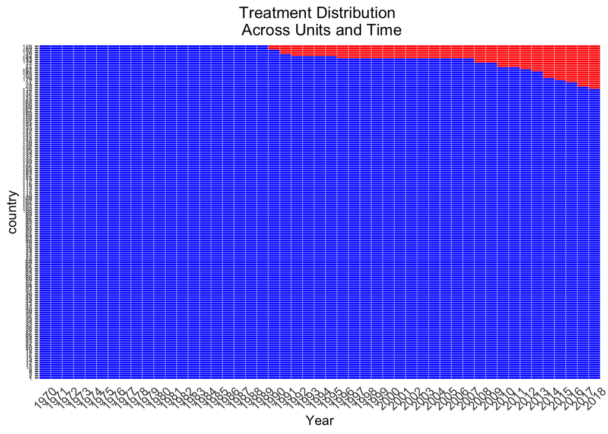

```r
# Display distribution of treatment variable within data (represented in red)
DisplayTreatment(unit.id = "country_code",
                 time.id = "Year", legend.position = "none",
                 xlab = "Year", ylab = "country",
                 treatment = "treatment", data = df)
```

```r
# Create sets of matching treated units to control units and determine the weights for each control unit
PM.results.none <- PanelMatch(lag = 4, time.id = "Year", unit.id = "country_code",
                         treatment = "treatment", refinement.method = "none",
                         data = df, match.missing = TRUE,
                         size.match = 5, qoi = "att", outcome.var = "emissions",
                         lead = 0:4, forbid.treatment.reversal = FALSE,
                         use.diagonal.variance.matrix = TRUE)
```

```r
# Use Mahalanobis distance matching
PM.results <- PanelMatch(lag = 4, time.id = "Year", unit.id = "country_code",
                         treatment = "treatment", refinement.method = "mahalanobis",
                         data = df, match.missing = TRUE,
                         covs.formula = ~ gdppc + Population + Fertility,
                         size.match = 5, qoi = "att" , outcome.var = "emissions",
                         lead = 0:4, forbid.treatment.reversal = FALSE,
                         use.diagonal.variance.matrix = TRUE)
```

```r
# Lagged values Mahalanobis distance matching
PM.results1 <- PanelMatch(lag = 4, time.id = "Year", unit.id = "country_code",
                         treatment = "treatment", refinement.method = "mahalanobis",
                         data = df, match.missing = TRUE,
                         covs.formula = ~ I(lag(gdppc, 1:4)) +
                           I(lag(Population, 1:4)) +
                           I(lag(Fertility, 1:4)) +
                           I(lag(emissions, 1:4)), # lags
                         size.match = 5, qoi = "att", outcome.var = "emissions",
                         lead = 0:4, forbid.treatment.reversal = FALSE,
                         use.diagonal.variance.matrix = TRUE)
```

Now that we have different matching and weighting possibilities, we will use covariate balance tables to choose the best model for further analysis. Note that I did not use propensity score matching because there were limited number of matches.

```r
summary(PM.results.none$att)
```

```
## $overview
##    country_code Year matched.set.size
## 1            42 1992              129
## 2            55 1990              132
## 3            58 2014              119
## 4            72 2010              124
## 5            77 2010              124
## 6            81 2012              123
## 7           103 2014              119
## 8           114 2008              126
## 9           120 1991              130
## 10          128 1990              132
## 11          144 1996              128
## 12          148 2014              119
## 13          152 1991              130
## 14          153 2008              126
## 15          167 2013              122
##
## $set.size.summary
##    Min. 1st Qu.  Median    Mean 3rd Qu.    Max.
##   119.0   122.5   126.0   125.5   129.5   132.0
##
## $number.of.treated.units
## [1] 15
##
## $num.units.empty.set
## [1] 0
##
## $lag
## [1] 4
```

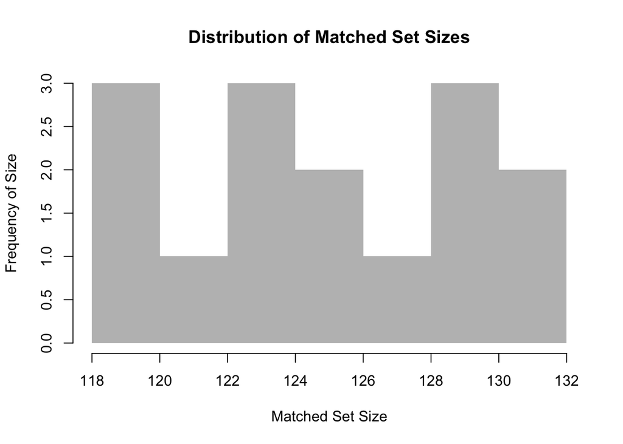

```r
plot(PM.results.none$att)
```

```r
# Covariate balance tables
get_covariate_balance(PM.results.none$att, df, covariates = c('gdppc', 'Population',
                                                         'Fertility', 'emissions'), plot = FALSE, ylim = c(-2,2))
```

```
##        gdppc Population Fertility emissions
## t_4 1.573986 -0.1809702 -5.653637 0.2375909
## t_3 1.578307 -0.1897384 -5.452527 0.2075156
## t_2 1.572509 -0.1989132 -5.254124 0.1958354
## t_1 1.565128 -0.2090071 -5.076611 0.1882795
## t_0 1.568980 -0.2191036 -4.917760 0.1559899
```

```r
get_covariate_balance(PM.results$att, df, covariates = c('gdppc', 'Population',
                                                         'Fertility', 'emissions'), plot = FALSE, ylim = c(-2,2))
```

```
##        gdppc Population Fertility emissions
## t_4 1.611029 0.06037861 -5.189295 0.4511161
## t_3 1.610575 0.05529593 -4.991314 0.4382125
## t_2 1.614358 0.04912887 -4.800636 0.4350622
## t_1 1.617832 0.04168611 -4.637545 0.4360364
## t_0 1.623161 0.03385483 -4.494333 0.4140819
```

```r
get_covariate_balance(PM.results1$att, df, covariates = c('gdppc', 'Population',
                                                         'Fertility', 'emissions'), plot = FALSE, ylim = c(-2,2))
```

```
##         gdppc Population  Fertility emissions
## t_4 0.6660306  0.3373572 -1.3903303 0.4349581
## t_3 0.6608417  0.3390550 -1.2734890 0.4292266
## t_2 0.6397183  0.3405779 -1.1558363 0.4283131
## t_1 0.6310038  0.3411686 -1.0633369 0.4333829
## t_0 0.6489127  0.3418486 -0.9919339 0.4116878
```

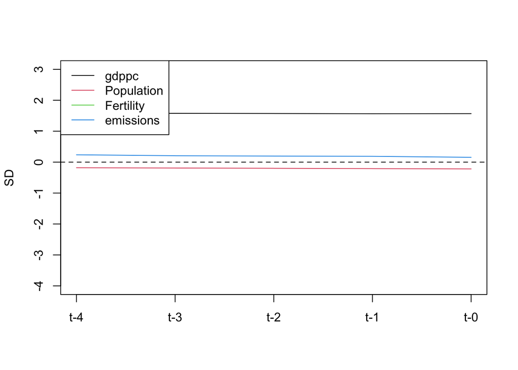

```r
# Plot covariate balances
get_covariate_balance(PM.results.none$att,
                      data = df,
                      covariates = c('gdppc', 'Population', 'Fertility', 'emissions'),
                      plot = TRUE, # visualize by setting plot to TRUE
                      ylim = c(-4, 3))
```

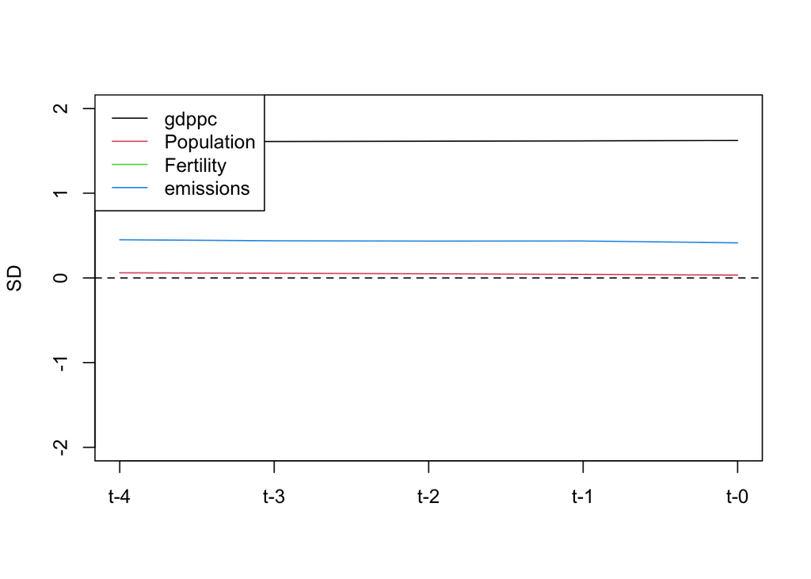

```r
get_covariate_balance(PM.results$att,
                      data = df,
                      covariates = c('gdppc', 'Population', 'Fertility', 'emissions'),
                      plot = TRUE, # visualize by setting plot to TRUE
                      ylim = c(-2, 2))
```

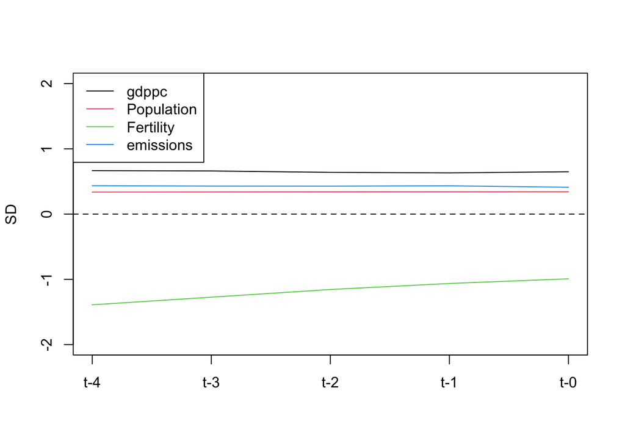

```r
get_covariate_balance(PM.results1$att,
                      data = df,
                      covariates = c('gdppc', 'Population', 'Fertility', 'emissions'),
                      plot = TRUE, # visualize by setting plot to TRUE
                      ylim = c(-2, 2))
```

While there is some unevenness in our covairate balances, the last model (`PM.result1`) looks like the best one out of the three. It uses lagged values on a Mahalanobis distance matching method. Below, we will apply this to the difference-in-difference approach to get average treatment effect.

```r
PE.results <- PanelEstimate(sets = PM.results1, data = df)
names(PE.results)
```

```
##  [1] "estimates"              "bootstrapped.estimates" "bootstrap.iterations"
##  [4] "standard.error"         "method"                 "lag"
##  [7] "lead"                   "confidence.level"       "qoi"
## [10] "matched.sets"
```

```r
PE.results[['estimates']]
```

```
##        t+0        t+1        t+2        t+3        t+4
##  -7095.811  -4340.528  -6570.553  -9065.459 -10796.747
```

```r
summary(PE.results)
```

```
## Weighted Difference-in-Differences with Mahalanobis Distance
## Matches created with 4 lags
##
## Standard errors computed with 1000 Weighted bootstrap samples
##
## Estimate of Average Treatment Effect on the Treated (ATT) by Period:
```

```
## $summary
##       estimate std.error      2.5%    97.5%
## t+0  -7095.811  4954.782 -16266.48 2906.549
## t+1  -4340.528  6582.904 -16752.02 9323.534
## t+2  -6570.553  6169.473 -17675.52 6186.391
## t+3  -9065.459  6890.980 -21548.31 4454.044
## t+4 -10796.747  7324.496 -23923.05 3827.369
##
## $lag
## [1] 4
##
## $iterations
## [1] 1000
##
## $qoi
## [1] "att"
```

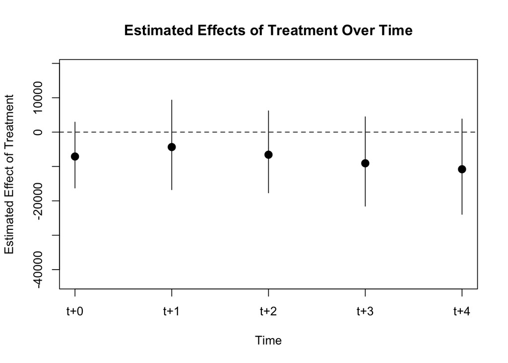

```r
plot(PE.results)
```

# Conclusion

From the above summary statistic and plots, we see that carbon pricing interventions help decrease greenhouse gas emissions, but the difference is statistically insignificant (estimates are within 95% confidence interval). While this is the case, further study can be done to this model to verify the conclusion. This may be suggestive evidence that carbon pricing policies alone are not enough for us to help reduce greenhouse gas emission and reach our climate goals.

Examples of further steps/study include:

- adding more covariates to the model to adjust for better matching or weighting
- keeping in mind that other methods in addition to carbon taxing can be used
- trying difference dependent variables like average temperature changes to further evaluate carbon pricing interventions